# Jupyter_Intro

## 1. Jupyter UI

```python
from google.colab import files
from IPython.display import Image
```

```python
uploaded = files.upload()
```

Upload widget is only available when the cell has been executed in the current browser session. Please rerun this cell to enable.

```
Saving Jupyter_UI.png to Jupyter_UI.png
```

[figure not shown]

```python
Image("Jupyter_UI.png")
```

This is how a typical Jupyter UI looks like. The first step in working on any project is to create a 'New Folder'. So let us see how one can create a 'New Folder'.

## 2. Creating & Renaming a New Folder

To create a New Folder, select the dropdown 'New' on the extreme right of the UI and then select 'Folder'.

```python
uploaded = files.upload()
```

Upload widget is only available when the cell has been executed in the current browser session. Please rerun this cell to enable.

```
Saving New_Folder_1.png to New_Folder_1.png
```

[figure not shown]

```python
Image('New_Folder_1.png')
```

Once done a folder named 'Untitled Folder' will be created in the Jupyter UI. Now since for every project we need to label a name, we have to Rename this folder so that it is easy for us to identify. To Rename this folder first check the checkbox next to it.

```python
uploaded = files.upload()
```

Upload widget is only available when the cell has been executed in the current browser session. Please rerun this cell to enable.

```
Saving New_Folder_2.png to New_Folder_2.png
```

[figure not shown]

```python
Image('New_Folder_2.png', width = 800)
```

Once clicked go to the top of the UI. On the extreme left, you will notice an option 'Rename'. Click on it.

```python
uploaded = files.upload()
```

Upload widget is only available when the cell has been executed in the current browser session. Please rerun this cell to enable.

```
Saving New_Folder_3.png to New_Folder_3.png
```

[figure not shown]

```python
Image('New_Folder_3.png', width = 800)
```

Once clicked, a new pop up window 'Rename directory' will open, type the name you want to assign to the folder. Say to give an example, I have used 'demo' as a name. Once renamed, click on 'Rename'.

```python
uploaded = files.upload()
```

Upload widget is only available when the cell has been executed in the current browser session. Please rerun this cell to enable.

```
Saving New_Folder_4.png to New_Folder_4.png
```

[figure not shown]

```python
Image('New_Folder_4.png', width = 800)
```

This will rename the name of the folder as the one you assigned. To give an example, my folder has been renamed to 'demo'.

```python
uploaded = files.upload()
```

Upload widget is only available when the cell has been executed in the current browser session. Please rerun this cell to enable.

```
Saving New_Folder_5.png to New_Folder_5.png
```

[figure not shown]

```python
Image('New_Folder_5.png', width = 800)
```

This is how you create & rename a folder in Jupyter notebook.

## 3. Uploading a file inside the Folder

Once you have created a folder. The next step is upload the essential datasets (for e.g. excel files) inside the folder. Let us first check how the UI inside the folder looks like.

```python
uploaded = files.upload()
```

Upload widget is only available when the cell has been executed in the current browser session. Please rerun this cell to enable.

```
Saving upload_1.png to upload_1.png
```

[figure not shown]

```python
Image('upload_1.png')
```

Since, we have no data files or a Jupyter notebook it is completely empty. Now let us upload a data file inside this folder. This can be done by clicking on the 'Upload' button on the right side of the UI.

```python
uploaded = files.upload()
```

Upload widget is only available when the cell has been executed in the current browser session. Please rerun this cell to enable.

```
Saving upload_2.png to upload_2.png
```

[figure not shown]

```python
Image('upload_2.png')
```

Once you click on upload, a new pop up window will open which will list us all the data files from our local PC. Select the right file and click on 'Open'. To give an example, I have selected 'adult_new' as a data file and then clicked on Open.

```python
uploaded = files.upload()
```

Upload widget is only available when the cell has been executed in the current browser session. Please rerun this cell to enable.

```
Saving upload_3.png to upload_3.png
```

[figure not shown]

```python
Image('upload_3.png')
```

Once done, the Jupyter UI will again ask for an option of 'Upload', so click on it.

```python
uploaded = files.upload()
```

Upload widget is only available when the cell has been executed in the current browser session. Please rerun this cell to enable.

```
Saving upload_4.png to upload_4.png
```

[figure not shown]

```python
Image('upload_4.png')
```

Once done, the data file will be uploaded. One can see that 'adult_new' dataset is now sucessfully uploaded. This is how one can upload files inside the folder.

```python
uploaded = files.upload()
```

Upload widget is only available when the cell has been executed in the current browser session. Please rerun this cell to enable.

```
Saving upload_5.png to upload_5.png
```

[figure not shown]

```python
Image('upload_5.png')
```

## 4. Creating a Notebook

Now that we have our Folder and dataset ready , it is time to create a Jupyter notebook. Jupyter notebook is where we are going to write our code. To create a new notebook, click on the New button inside the folder.

```python
uploaded = files.upload()
```

Upload widget is only available when the cell has been executed in the current browser session. Please rerun this cell to enable.

```
Saving notebook_1.png to notebook_1.png
```

[figure not shown]

```python
Image('notebook_1.png')
```

once done, click on 'Python 3(ipykernel)'.

```python
uploaded = files.upload()
```

Upload widget is only available when the cell has been executed in the current browser session. Please rerun this cell to enable.

```
Saving notebook_2.png to notebook_2.png
```

[figure not shown]

```python
Image('notebook_2.png')
```

This will open a new Jupyter notebook in a new window.

```python
uploaded = files.upload()
```

Upload widget is only available when the cell has been executed in the current browser session. Please rerun this cell to enable.

```
Saving notebook_3.png to notebook_3.png
```

[figure not shown]

```python
Image('notebook_3.png')
```

To rename a Jupyter notebook, click on the name 'Untitled'.

```python
uploaded = files.upload()
```

Upload widget is only available when the cell has been executed in the current browser session. Please rerun this cell to enable.

```
Saving notebook_4.png to notebook_4.png
```

[figure not shown]

```python
Image('notebook_4.png')
```

This will open a pop up window which will ask the user to enter a new notebook name. Enter the desire name you want and click on 'Rename'. Here I have entered 'demo' as the name of the notebook and clicked on Rename.

```python
uploaded = files.upload()
```

Upload widget is only available when the cell has been executed in the current browser session. Please rerun this cell to enable.

```
Saving notebook_5.png to notebook_5.png
```

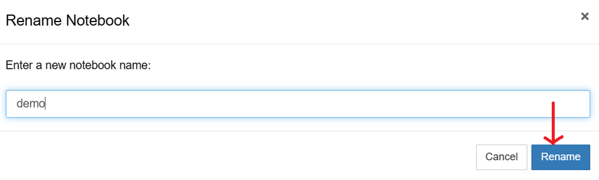

```python
Image('notebook_5.png', width = 800)
```

Once done. the notebook will be renamed.

```python
uploaded = files.upload()
```

Upload widget is only available when the cell has been executed in the current browser session. Please rerun this cell to enable.

```
Saving notebook_6.png to notebook_6.png
```

[figure not shown]

```python
Image('notebook_6.png')
```

Additionally if you go back to your file directory. You will see '.ipynb' file generated. This is nothing but the Jupyter notebook. Jupyter notebook are saved as '.ipynb' extension.

```python
uploaded = files.upload()
```

Upload widget is only available when the cell has been executed in the current browser session. Please rerun this cell to enable.

```
Saving notebook_7.png to notebook_7.png
```

[figure not shown]

```python
Image('notebook_7.png')
```

## 5. Running a cell

If one wants to run a cell, there are 3 ways.

1. **Click shift + Enter : It runs the cell and goes to the next line.**
2. Click on Run icon : It runs the selected cell only.
3. Click on Cell option in Menu bar: It has variety of options to execute a cell.

However, the one I prefer is clicking 'Shift + Enter'.

```python
uploaded = files.upload()
```

Upload widget is only available when the cell has been executed in the current browser session. Please rerun this cell to enable.

```
Saving cell_1.png to cell_1.png
```

[figure not shown]

```python
Image('cell_1.png')
```

```python
uploaded = files.upload()
```

Upload widget is only available when the cell has been executed in the current browser session. Please rerun this cell to enable.

```
Saving cell_1_2.png to cell_1_2.png
```

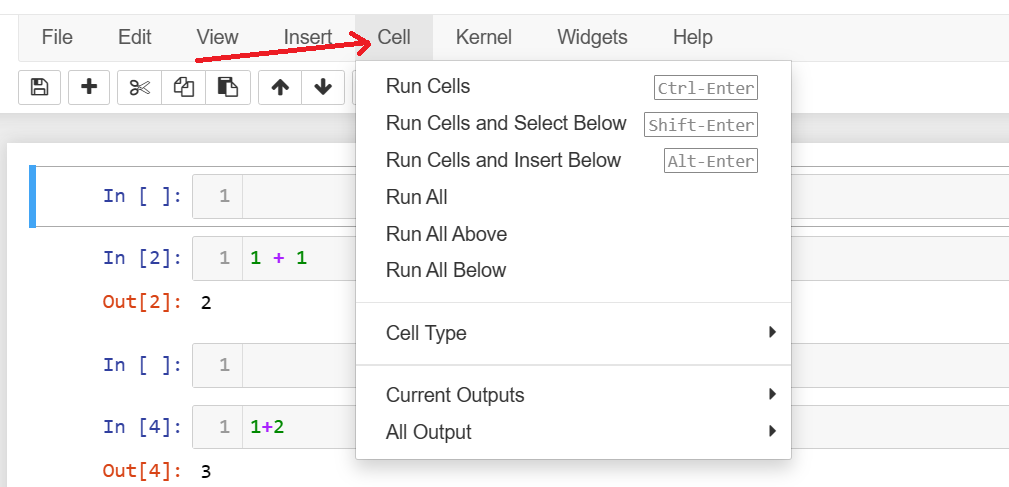

```python
Image('cell_1_2.png', width = 800)
```

Let us see how the output looks like after we run a cell.

```python
uploaded = files.upload()
```

Upload widget is only available when the cell has been executed in the current browser session. Please rerun this cell to enable.

```
Saving cell_2.png to cell_2.png
```

[figure not shown]

```python
Image('cell_2.png', width = 800)
```

So in the input cell (In [2]) above I have done a simple mathematical operation of adding 2 numbers '1' and '1'. The output (Out[2]) is printed as '2' and the cursor moves to the next cell after we run it using 'Shift + Enter.'

I would strongly recommend everyone to run a cell using 'Shift + Enter'.

## 6. Moving a cell up & down

To move a cell up & down, first select the cell you want to move up/down and then click on the up-down navigation arrows.

To give an example, I want to move the active cell In [2] down. To do this, I will select the down arrow

```python
uploaded = files.upload()
```

Upload widget is only available when the cell has been executed in the current browser session. Please rerun this cell to enable.

```
Saving cell_3.png to cell_3.png
```

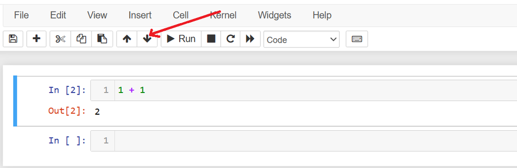

```python
Image('cell_3.png', width = 800)
```

Once selected, the cell will move down.

```python
uploaded = files.upload()
```

Upload widget is only available when the cell has been executed in the current browser session. Please rerun this cell to enable.

```
Saving cell_4.png to cell_4.png
```

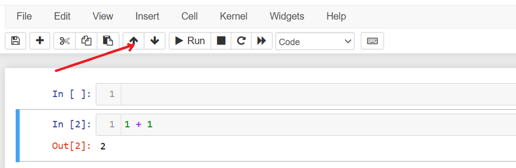

```python
Image('cell_4.png', width = 800)
```

Now if we want to move up, select the up arrow.

```python
uploaded = files.upload()
```

Upload widget is only available when the cell has been executed in the current browser session. Please rerun this cell to enable.

```
Saving cell_5.png to cell_5.png
```

[figure not shown]

```python
Image('cell_5.png', width = 800)
```

This is how one can move a cell up & down.

## 7. Inserting a cell above/below

To insert a cell below, either click on '+' sign or go to Insert tab and select 'Insert Cell Below'

```python
uploaded = files.upload()
```

Upload widget is only available when the cell has been executed in the current browser session. Please rerun this cell to enable.

```
Saving insert_1.png to insert_1.png
```

[figure not shown]

```python
Image('insert_1.png', width = 800)
```

This will insert a cell below the active cell. To give an example, our active cell is the one that contains '1+1', so after inserting a cell below we will get an output as follows.

```python
uploaded = files.upload()
```

Upload widget is only available when the cell has been executed in the current browser session. Please rerun this cell to enable.

```
Saving insert_2.png to insert_2.png
```

[figure not shown]

```python
Image('insert_2.png', width = 800)
```

To insert a cell above, go to insert tab and click on 'Insert Cell Above'.

```python
uploaded = files.upload()
```

Upload widget is only available when the cell has been executed in the current browser session. Please rerun this cell to enable.

```
Saving insert_3.png to insert_3.png
```

[figure not shown]

```python
Image('insert_3.png', width = 800)
```

This will insert cell above the active cell. In this example active cell is '1+1'.

```python
uploaded = files.upload()
```

Upload widget is only available when the cell has been executed in the current browser session. Please rerun this cell to enable.

```
Saving insert_4.png to insert_4.png
```

[figure not shown]

```python
Image('insert_4.png', width = 800)
```

This is how one can insert a cell in Jupyter notebook.

## 8. Types of cell

There are namely 4 types of cell namely:

a) Code cell

b) Markdown

c) Raw NBConvert

d) Heading

```python
uploaded = files.upload()
```

Upload widget is only available when the cell has been executed in the current browser session. Please rerun this cell to enable.

```
Saving type_1.png to type_1.png
```

[figure not shown]

```python
Image('type_1.png', width = 800)
```

Code cell is where we actually write & execute a code. To give an example, the following cell is a code cell.

```python
# Code cell
1+1
```

```
2
```

Markdown cell is where one can write a comment or content. One cannot execute a code in a markdown cell. This cell itself is an example of Markdown cell. Let me give you another example. To select a Markdown cell go to Code and click on Markdown and then write a comment in the cell.

```python
uploaded = files.upload()
```

Upload widget is only available when the cell has been executed in the current browser session. Please rerun this cell to enable.

```
Saving markdown_cell.png to markdown_cell.png
```

[figure not shown]

```python
Image('markdown_cell.png', width = 800)
```

This is a Markdown cell <------

Heading cell is the one to give a title or a Heading. To select a Heading cell, go to Code dropdown and select Heading. Once done type some title/ heading.

```python
uploaded = files.upload()
```

Upload widget is only available when the cell has been executed in the current browser session. Please rerun this cell to enable.

```
Saving heading_cell.png to heading_cell.png
```

[figure not shown]

```python
Image('heading_cell.png', width = 800)
```

# This is a single '#' heading.

## This is a double '##' heading.

### This is a triple '###' heading.

To view how I have written the heading click on the above headings.

Generally the headings are prefixed by '#'.

It looks like **# Heading**

And double hash heading will look like: **## Heading**

And Triple hash would look like: **### Heading**.

The heading single, double and triple # would be useful when you write a section and subsections.

## 9. Comment, Bold & Italics

To comment in a code cell, one simply writes the comment prefixed by '#'. It might sound similar to a heading but remember **# in heading is written in a 'markdown cell' whereas comment is written in a 'code cell'**. In the code below **'# Adding 2 numbers'** is a comment that gives information about the underlying code.

```python
# Adding 2 numbers
1+1
```

```
2
```

To bold a word or a sentence in a markdown cell, simply use '**' before and after the word.

To give an example.

**This is a bold sentence**

Double click on this cell to understand how I have written the text above.

To make a word or sentence italics, use '***' before and after the word.

To give an example

***This is an italics sentence***

Double click on this cell to understand how I have written the text above.

## 10. Restarting a Kernel

At times due to a server lag, the code might stop running or may take a lot of time to run. In such scenario, one must restart the Kernel. To restart the kernel go to 'Kernel tab' and then you can either click on 'Restart' or 'Restart & Run All'.

I won't recommend 'Restart the Kernel' since all the output will be erased. So you have to run every cell again one by one.

Instead of doing this, I would strongly recommend you guys to select **'Restart & Run All'**, this will not only restart the kernel but run all the cells for you at once.

```python
uploaded = files.upload()
```

Upload widget is only available when the cell has been executed in the current browser session. Please rerun this cell to enable.

```
Saving kernel_1.png to kernel_1.png
```

[figure not shown]

```python
Image('kernel_1.png', width = 800)
```